# **Phase-02- Data Cleaning & Manipulation**

```python
import numpy as  np
import pandas as pd
import warnings
warnings.filterwarnings('ignore')
```

#### Loading the Dataset

```python
df = pd.read_csv(r"C:/Datasets/hotel_booking.csv")
```

#### 1. Handling Missing Data

```python
df.isnull().sum()
```

```
hotel                                  0
is_canceled                            0
lead_time                              0
arrival_date_year                      0
arrival_date_month                     0
arrival_date_week_number               0
arrival_date_day_of_month              0
stays_in_weekend_nights                0
stays_in_week_nights                   0
adults                                 0
children                               4
babies                                 0
meal                                   0
country                              488
market_segment                         0
distribution_channel                   0
is_repeated_guest                      0
previous_cancellations                 0
previous_bookings_not_canceled         0
reserved_room_type                     0
assigned_room_type                     0
booking_changes                        0
deposit_type                           0
agent                              16340
company                           112593
days_in_waiting_list                   0
customer_type                          0
adr                                    0
required_car_parking_spaces            0
total_of_special_requests              0
reservation_status                     0
reservation_status_date                0
name                                   0
email                                  0
phone-number                           0
credit_card                            0
dtype: int64
```

#### Observation:

1. **Mostly complete dataset** → Many columns have **0 missing values**.
2. **Children:** Only 4 missing entries → negligible, can drop or impute.
3. **Country:** 488 missing → very small compared to 119k rows.
4. **Agent:** 16,340 missing (~14%) → may represent direct bookings.
5. **Company:** 112,593 missing (~94%) → most guests do not book via company contracts.
6. Other columns (e.g., hotel, lead_time, adr, reservation_status) are **fully complete**.

#### Fill missing values using suitable methods such as: Mean or median (for numerical values) Mode or placeholder (for categorical values)

```python
df['children'] = df['children'].fillna(df['children'].median())
df['country'] = df['country'].fillna(df['country'].mode()[0])
df['agent'] = df['agent'].fillna('Unknown')
df['company'] = df['company'].fillna('Unknown')

print(df.isnull().sum())
```

```
hotel                             0
is_canceled                       0
lead_time                         0
arrival_date_year                 0
arrival_date_month                0
arrival_date_week_number          0
arrival_date_day_of_month         0
stays_in_weekend_nights           0
stays_in_week_nights              0
adults                            0
children                          0
babies                            0
meal                              0
country                           0
market_segment                    0
distribution_channel              0
is_repeated_guest                 0
previous_cancellations            0
previous_bookings_not_canceled    0
reserved_room_type                0
assigned_room_type                0
booking_changes                   0
deposit_type                      0
agent                             0
company                           0
days_in_waiting_list              0
customer_type                     0
adr                               0
required_car_parking_spaces       0
total_of_special_requests         0
reservation_status                0
reservation_status_date           0
name                              0
email                             0
phone-number                      0
credit_card                       0
dtype: int64
```

#### 2.Remove Duplicates

```python
df.duplicated().sum()
```

```
0
```

#### Observation:

> I checked for duplicate records using the **duplicated()** function.

No duplicates were found, which means the dataset is already clean and does not require duplicate removal.

#### 3 Fix Inconsistencies in Categorical Data

##### check for categorical Data

```python
categorical_cols = df.select_dtypes(include="object").columns
print(categorical_cols)
```

```
Index(['hotel', 'arrival_date_month', 'meal', 'country', 'market_segment',
       'distribution_channel', 'reserved_room_type', 'assigned_room_type',
       'deposit_type', 'agent', 'company', 'customer_type',
       'reservation_status', 'reservation_status_date', 'name', 'email',
       'phone-number', 'credit_card'],
      dtype='object')
```

#### converting object type into categorical data

```python
for col in categorical_cols:
    df[col] = df[col].astype("category")
```

```python
df.info()
```

```
<class 'pandas.core.frame.DataFrame'>
RangeIndex: 119390 entries, 0 to 119389
Data columns (total 36 columns):
 #   Column                          Non-Null Count   Dtype
---  ------                          --------------   -----
 0   hotel                           119390 non-null  category
 1   is_canceled                     119390 non-null  int64
 2   lead_time                       119390 non-null  int64
 3   arrival_date_year               119390 non-null  int64
 4   arrival_date_month              119390 non-null  category
 5   arrival_date_week_number        119390 non-null  int64
 6   arrival_date_day_of_month       119390 non-null  int64
 7   stays_in_weekend_nights         119390 non-null  int64
 8   stays_in_week_nights            119390 non-null  int64
 9   adults                          119390 non-null  int64
```

[output cut: 28 more lines]

All categorical text columns were converted from object type to category type. This reduces memory usage and helps improve efficiency in analysis and modeling

#### Cleaning the categorial columns

```python
for col in df.select_dtypes(include='object').columns:
    df[col] = df[col].str.strip().str.lower()
```

```python
df.head()
```

|  | hotel | is_canceled | lead_time | arrival_date_year | arrival_date_month | arrival_date_week_number | arrival_date_day_of_month | stays_in_weekend_nights | stays_in_week_nights | adults | ... | customer_type | adr | required_car_parking_spaces | total_of_special_requests | reservation_status | reservation_status_date | name | email | phone-number | credit_card |
| --- | --- | --- | --- | --- | --- | --- | --- | --- | --- | --- | --- | --- | --- | --- | --- | --- | --- | --- | --- | --- | --- |
| 0 | Resort Hotel | 0 | 342 | 2015 | July | 27 | 1 | 0 | 0 | 2 | ... | Transient | 0.0 | 0 | 0 | Check-Out | 2015-07-01 | Ernest Barnes | Ernest.Barnes31@outlook.com | 669-792-1661 | ************4322 |
| 1 | Resort Hotel | 0 | 737 | 2015 | July | 27 | 1 | 0 | 0 | 2 | ... | Transient | 0.0 | 0 | 0 | Check-Out | 2015-07-01 | Andrea Baker | Andrea_Baker94@aol.com | 858-637-6955 | ************9157 |
| 2 | Resort Hotel | 0 | 7 | 2015 | July | 27 | 1 | 0 | 1 | 1 | ... | Transient | 75.0 | 0 | 0 | Check-Out | 2015-07-02 | Rebecca Parker | Rebecca_Parker@comcast.net | 652-885-2745 | ************3734 |
| 3 | Resort Hotel | 0 | 13 | 2015 | July | 27 | 1 | 0 | 1 | 1 | ... | Transient | 75.0 | 0 | 0 | Check-Out | 2015-07-02 | Laura Murray | Laura_M@gmail.com | 364-656-8427 | ************5677 |
| 4 | Resort Hotel | 0 | 14 | 2015 | July | 27 | 1 | 0 | 2 | 2 | ... | Transient | 98.0 | 0 | 1 | Check-Out | 2015-07-03 | Linda Hines | LHines@verizon.com | 713-226-5883 | ************5498 |

5 rows × 36 columns

#### 4. Converting Data types

```python
# Convert date column
df["reservation_status_date"] = pd.to_datetime(df["reservation_status_date"], errors="coerce")

# Numeric columns
numeric_cols = [
    "lead_time", "adr", "stays_in_week_nights", "stays_in_weekend_nights",
    "adults", "children", "babies", "previous_cancellations",
    "previous_bookings_not_canceled", "required_car_parking_spaces",
    "total_of_special_requests"
]

for col in numeric_cols:
    df[col] = pd.to_numeric(df[col], errors="coerce")

# Categorical columns
categorical_cols = [
    "hotel", "meal", "country", "market_segment", "distribution_channel",
    "reserved_room_type", "assigned_room_type", "deposit_type",
    "customer_type", "reservation_status"
]

for col in categorical_cols:
    df[col] = df[col].astype("category")
```

```python
df.info()
```

```
<class 'pandas.core.frame.DataFrame'>
RangeIndex: 119390 entries, 0 to 119389
Data columns (total 36 columns):
 #   Column                          Non-Null Count   Dtype
---  ------                          --------------   -----
 0   hotel                           119390 non-null  category
 1   is_canceled                     119390 non-null  int64
 2   lead_time                       119390 non-null  int64
 3   arrival_date_year               119390 non-null  int64
 4   arrival_date_month              119390 non-null  category
 5   arrival_date_week_number        119390 non-null  int64
 6   arrival_date_day_of_month       119390 non-null  int64
 7   stays_in_weekend_nights         119390 non-null  int64
 8   stays_in_week_nights            119390 non-null  int64
 9   adults                          119390 non-null  int64
```

[output cut: 28 more lines]

#### Importing the modules

```python
import numpy as np
import pandas as pd
import matplotlib.pyplot as plt
import seaborn as sns

from datetime import datetime

from IPython.core.interactiveshell import InteractiveShell
InteractiveShell.ast_node_interactivity = 'all'

import warnings
warnings.filterwarnings('ignore')

# choose a matplotlib style option
plt.style.use('fivethirtyeight')

# choose seaborn style option
sns.set_style('darkgrid')
```

#### Categorical vs Categorical

##### column names

```python
df.columns
```

```
Index(['hotel', 'is_canceled', 'lead_time', 'arrival_date_year',
       'arrival_date_month', 'arrival_date_week_number',
       'arrival_date_day_of_month', 'stays_in_weekend_nights',
       'stays_in_week_nights', 'adults', 'children', 'babies', 'meal',
       'country', 'market_segment', 'distribution_channel',
       'is_repeated_guest', 'previous_cancellations',
       'previous_bookings_not_canceled', 'reserved_room_type',
       'assigned_room_type', 'booking_changes', 'deposit_type', 'agent',
       'company', 'days_in_waiting_list', 'customer_type', 'adr',
       'required_car_parking_spaces', 'total_of_special_requests',
       'reservation_status', 'reservation_status_date', 'name', 'email',
       'phone-number', 'credit_card'],
      dtype='object')
```

```python
df.info()
```

```
<class 'pandas.core.frame.DataFrame'>
RangeIndex: 119390 entries, 0 to 119389
Data columns (total 36 columns):
 #   Column                          Non-Null Count   Dtype
---  ------                          --------------   -----
 0   hotel                           119390 non-null  category
 1   is_canceled                     119390 non-null  int64
 2   lead_time                       119390 non-null  int64
 3   arrival_date_year               119390 non-null  int64
 4   arrival_date_month              119390 non-null  category
 5   arrival_date_week_number        119390 non-null  int64
 6   arrival_date_day_of_month       119390 non-null  int64
 7   stays_in_weekend_nights         119390 non-null  int64
 8   stays_in_week_nights            119390 non-null  int64
 9   adults                          119390 non-null  int64
```

[output cut: 28 more lines]

```python
numerical_cols = df.select_dtypes(include=[int,float]).columns
```

```python
numerical_cols
```

```
Index(['is_canceled', 'lead_time', 'arrival_date_year',
       'arrival_date_week_number', 'arrival_date_day_of_month',
       'stays_in_weekend_nights', 'stays_in_week_nights', 'adults', 'children',
       'babies', 'is_repeated_guest', 'previous_cancellations',
       'previous_bookings_not_canceled', 'booking_changes',
       'days_in_waiting_list', 'adr', 'required_car_parking_spaces',
       'total_of_special_requests'],
      dtype='object')
```

```python
categorical_cols = df.select_dtypes(include='category').columns
```

```python
categorical_cols
```

```
Index(['hotel', 'arrival_date_month', 'meal', 'country', 'market_segment',
       'distribution_channel', 'reserved_room_type', 'assigned_room_type',
       'deposit_type', 'agent', 'company', 'customer_type',
       'reservation_status', 'reservation_status_date', 'name', 'email',
       'phone-number', 'credit_card'],
      dtype='object')
```

#### One Numerical column-total_of_special_requests

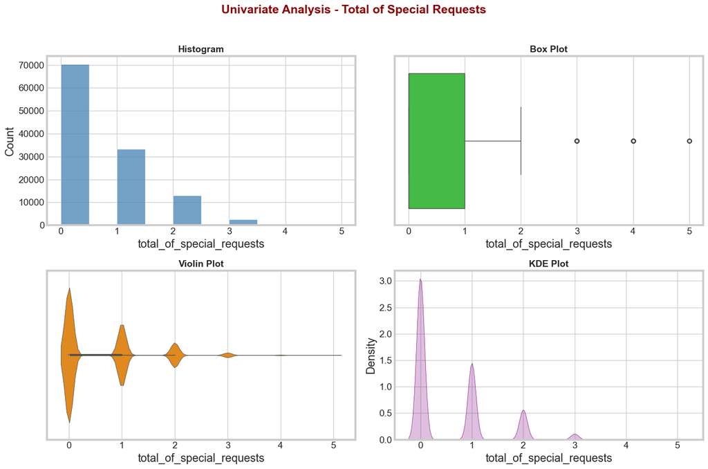

```python
import seaborn as sns
import matplotlib.pyplot as plt

sns.set_style("whitegrid")

fig, axs = plt.subplots(nrows=2, ncols=2, figsize=(15,10))
plt.suptitle("Univariate Analysis - Total of Special Requests", fontsize=18, color="darkred", weight="bold")

# Histogram
sns.histplot(data=df, x="total_of_special_requests", bins=10, color="#4682B4", ax=axs[0,0])
axs[0,0].set_title("Histogram", fontsize=14, weight="bold")

# Box plot
sns.boxplot(data=df, x="total_of_special_requests", color="#32CD32", ax=axs[0,1])
axs[0,1].set_title("Box Plot", fontsize=14, weight="bold")

# Violin plot
sns.violinplot(data=df, x="total_of_special_requests", color="#FF8C00", ax=axs[1,0])
axs[1,0].set_title("Violin Plot", fontsize=14, weight="bold")

# KDE plot
sns.kdeplot(data=df, x="total_of_special_requests", fill=True, color="#800080", ax=axs[1,1])
axs[1,1].set_title("KDE Plot", fontsize=14, weight="bold")

plt.savefig("C:\Datasets\one_numerical_univariate.png")
plt.tight_layout(rect=[0, 0, 1, 0.96])
plt.show();
```

#### One Categorial

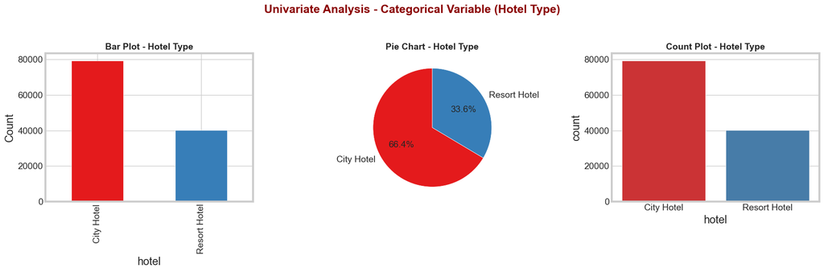

```python
import seaborn as sns
import matplotlib.pyplot as plt

fig, axs = plt.subplots(1, 3, figsize=(18,6))
plt.suptitle("Univariate Analysis - Categorical Variable (Hotel Type)", fontsize=18, color="darkred", weight="bold")

# Bright color palette
bright_colors = sns.color_palette("Set1")

# 1. Bar Plot
df['hotel'].value_counts().plot(kind='bar', ax=axs[0], color=bright_colors)
axs[0].set_title("Bar Plot - Hotel Type", fontsize=14, weight="bold")
axs[0].set_ylabel("Count")

# 2. Pie Chart
axs[1].pie(
    df['hotel'].value_counts(),
    labels=df['hotel'].value_counts().index,
    autopct="%.1f%%",
    colors=bright_colors,
    startangle=90,
    wedgeprops={"edgecolor":"white"}
)
axs[1].set_title("Pie Chart - Hotel Type", fontsize=14, weight="bold")

# 3. Count Plot
sns.countplot(data=df, x="hotel", palette="Set1", ax=axs[2])
axs[2].set_title("Count Plot - Hotel Type", fontsize=14, weight="bold")

plt.savefig("C:\Datasets\one_categorical_univariate.png")
plt.tight_layout(rect=[0,0,1,0.95])
plt.show();
```

#### Categorical vs Categorical

##### Categorical columns

```python
df.select_dtypes(include='category').columns
```

```
Index(['hotel', 'arrival_date_month', 'meal', 'country', 'market_segment',
       'distribution_channel', 'reserved_room_type', 'assigned_room_type',
       'deposit_type', 'agent', 'company', 'customer_type',
       'reservation_status', 'reservation_status_date', 'name', 'email',
       'phone-number', 'credit_card'],
      dtype='object')
```

#### Bivariate analysis of two categorial columns

```python
pd.crosstab(df['hotel'], df['customer_type'])
```

| customer_type hotel | Contract | Group | Transient | Transient-Party |
| --- | --- | --- | --- | --- |
| City Hotel | 2300 | 293 | 59404 | 17333 |
| Resort Hotel | 1776 | 284 | 30209 | 7791 |

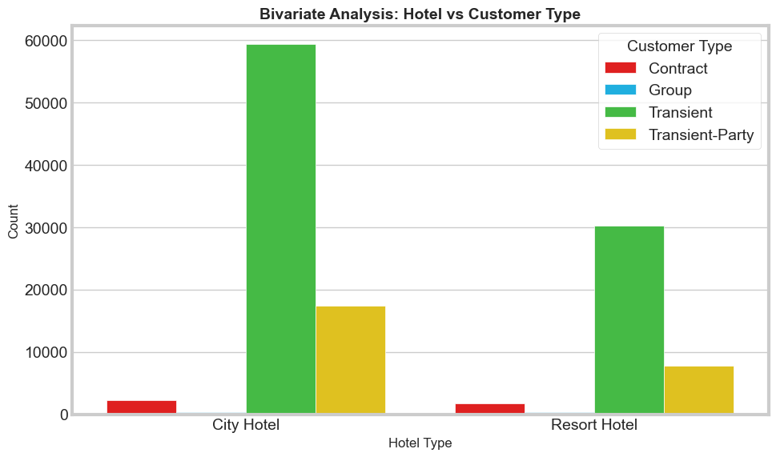

```python
plt.figure(figsize=(10,6))
sns.countplot(
    data=df,
    x='hotel',
    hue='customer_type',
    palette=['#FF0000','#00BFFF','#32CD32','#FFD700']  # Bright red, blue, green, gold
)
plt.title("Bivariate Analysis: Hotel vs Customer Type", fontsize=14, fontweight="bold")
plt.xlabel("Hotel Type", fontsize=12)
plt.ylabel("Count", fontsize=12)
plt.legend(title="Customer Type")

plt.savefig("C:\Datasets\Two_cat_bivariate.png")
plt.show();
```

```python
# Cross-tabulation
crosstab_result= pd.crosstab(df['deposit_type'], df['reservation_status'])
crosstab_result
```

| reservation_status deposit_type | Canceled | Check-Out | No-Show |
| --- | --- | --- | --- |
| No Deposit | 28522 | 74947 | 1172 |
| Non Refund | 14460 | 93 | 34 |
| Refundable | 35 | 126 | 1 |

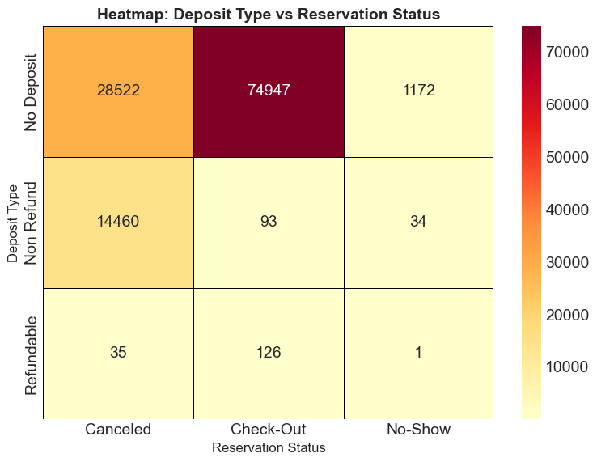

```python
plt.figure(figsize=(8,6))
sns.heatmap(
    crosstab_result,
    annot=True, fmt="d", cmap="YlOrRd",  # Bright Yellow-Orange-Red colormap
    linewidths=.5, linecolor='black'
)
plt.title("Heatmap: Deposit Type vs Reservation Status", fontsize=14, fontweight="bold")
plt.xlabel("Reservation Status", fontsize=12)
plt.ylabel("Deposit Type", fontsize=12)
plt.savefig("C:\Datasets\Heatmap.png")
plt.show();
```

```python
channel_crosstab= pd.crosstab(df['distribution_channel'], df['market_segment'])
channel_crosstab
```

| market_segment distribution_channel | Aviation | Complementary | Corporate | Direct | Groups | Offline TA/TO | Online TA | Undefined |
| --- | --- | --- | --- | --- | --- | --- | --- | --- |
| Corporate | 227 | 89 | 4788 | 90 | 1228 | 212 | 43 | 0 |
| Direct | 0 | 576 | 172 | 12276 | 1472 | 16 | 133 | 0 |
| GDS | 0 | 0 | 0 | 1 | 0 | 45 | 147 | 0 |
| TA/TO | 10 | 78 | 335 | 237 | 17111 | 23946 | 56153 | 0 |
| Undefined | 0 | 0 | 0 | 2 | 0 | 0 | 1 | 2 |

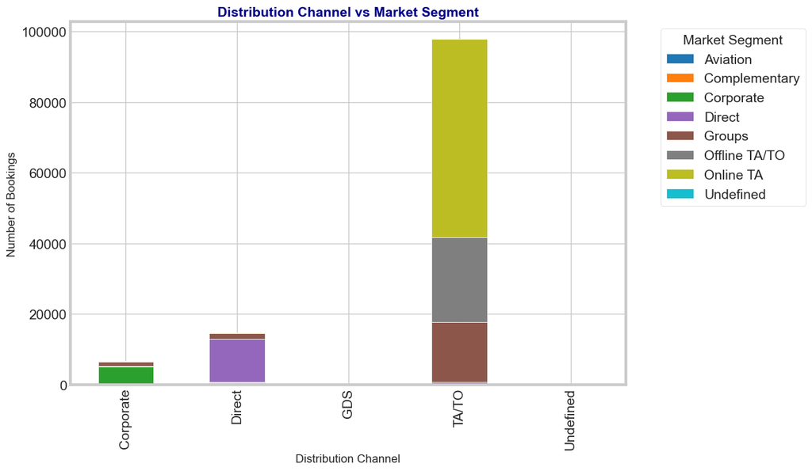

```python
channel_crosstab.plot(kind="bar", figsize=(12,7), colormap="tab10", stacked = True)

plt.title("Distribution Channel vs Market Segment", fontsize=14, fontweight="bold", color="darkblue")
plt.xlabel("Distribution Channel", fontsize=12)
plt.ylabel("Number of Bookings", fontsize=12)
plt.legend(title="Market Segment", bbox_to_anchor=(1.05, 1), loc='upper left')
plt.tight_layout()
plt.savefig("C:\Datasets\Bar.png")
plt.show();
```

#### Numerical columns:

```python
df.select_dtypes(include=[int,float]).columns
```

```
Index(['is_canceled', 'lead_time', 'arrival_date_year',
       'arrival_date_week_number', 'arrival_date_day_of_month',
       'stays_in_weekend_nights', 'stays_in_week_nights', 'adults', 'children',
       'babies', 'is_repeated_guest', 'previous_cancellations',
       'previous_bookings_not_canceled', 'booking_changes',
       'days_in_waiting_list', 'adr', 'required_car_parking_spaces',
       'total_of_special_requests'],
      dtype='object')
```

#### Bivariate analysis of two Numerical columns

```python
df[['stays_in_week_nights','adr']].corr()
```

|  | stays_in_week_nights | adr |
| --- | --- | --- |
| stays_in_week_nights | 1.000000 | 0.065237 |
| adr | 0.065237 | 1.000000 |

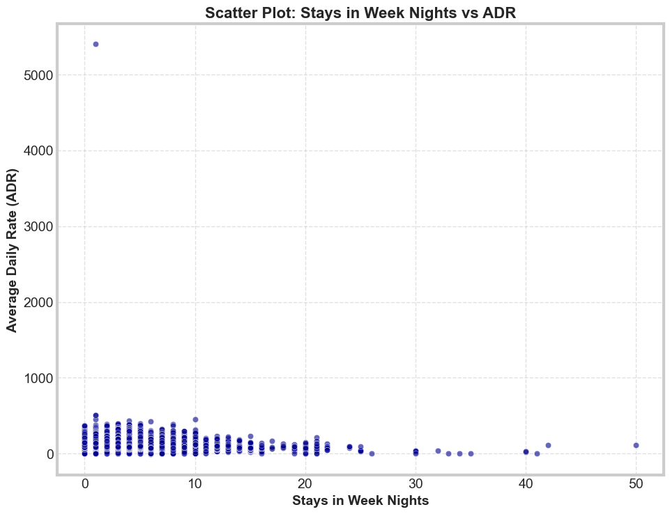

```python
import matplotlib.pyplot as plt
import seaborn as sns

plt.figure(figsize=(10,8))
sns.scatterplot(
    data=df,
    x='stays_in_week_nights',
    y='adr',
    color='darkblue',
    alpha=0.6,
    edgecolor='w'
)

# Title and axis labels with font styling
plt.title("Scatter Plot: Stays in Week Nights vs ADR", fontsize=16, fontweight='bold', fontname='Arial')
plt.xlabel("Stays in Week Nights", fontsize=14, fontweight='bold', fontname='Arial')
plt.ylabel("Average Daily Rate (ADR)", fontsize=14, fontweight='bold', fontname='Arial')

# Grid lines
plt.grid(True, linestyle="--", alpha=0.6)

# Save the figure
plt.savefig(r"C:\Datasets\Bivariate_two_num.png", dpi=300, bbox_inches="tight")

# Show plot
plt.show();
```

```python
df[['previous_cancellations','booking_changes']].corr()
```

|  | previous_cancellations | booking_changes |
| --- | --- | --- |
| previous_cancellations | 1.000000 | -0.026993 |
| booking_changes | -0.026993 | 1.000000 |

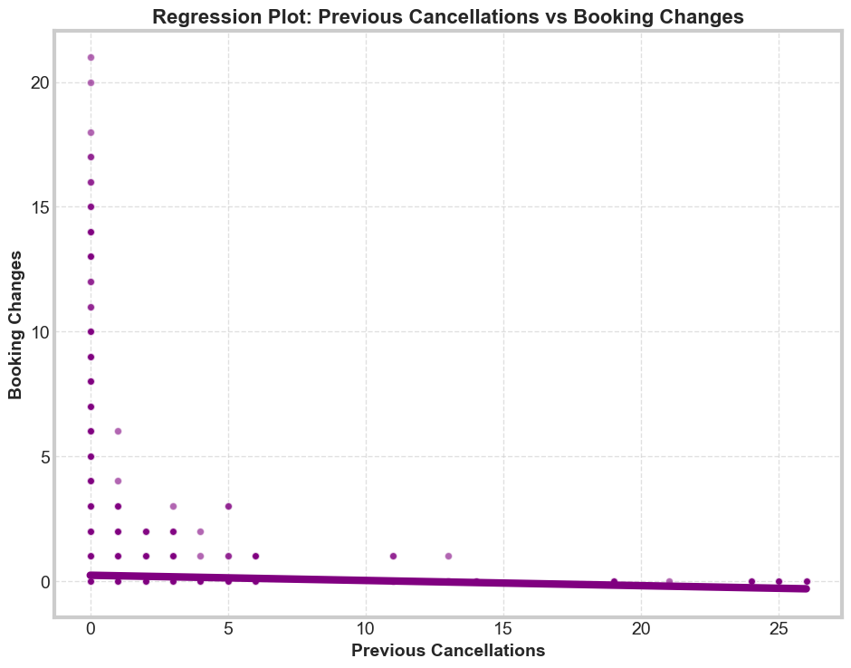

```python
import matplotlib.pyplot as plt
import seaborn as sns

# Create figure first
plt.figure(figsize=(10,8))

# Regression plot
sns.regplot(
    data=df,
    x='previous_cancellations',
    y='booking_changes',
    color='purple',
    scatter_kws={'alpha':0.6, 'edgecolor':'w'}
)

# Title and labels with font styling
plt.title("Regression Plot: Previous Cancellations vs Booking Changes", fontsize=16, fontweight='bold', fontname='Arial')
plt.xlabel("Previous Cancellations", fontsize=14, fontweight='bold', fontname='Arial')
plt.ylabel("Booking Changes", fontsize=14, fontweight='bold', fontname='Arial')

# Grid lines
plt.grid(True, linestyle="--", alpha=0.6)

# Save figure
plt.savefig(r"C:\Datasets\Regression_plot.png", dpi=300, bbox_inches="tight")

# Show plot
plt.show()
```

```python
df[['days_in_waiting_list','required_car_parking_spaces']].corr()
```

|  | days_in_waiting_list | required_car_parking_spaces |
| --- | --- | --- |
| days_in_waiting_list | 1.0000 | -0.0306 |
| required_car_parking_spaces | -0.0306 | 1.0000 |

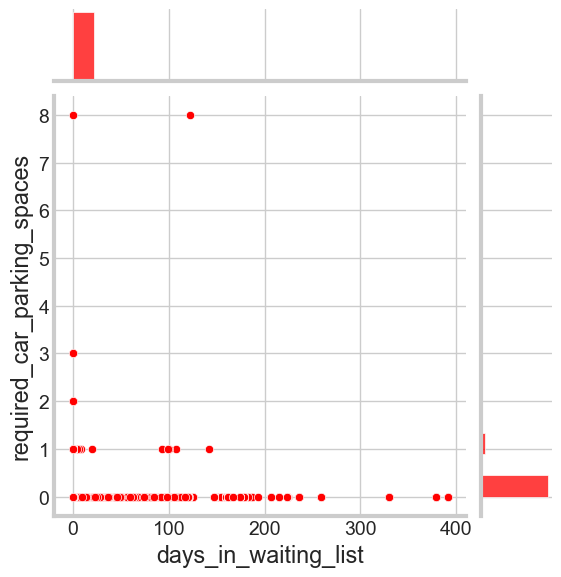

```python
sns.jointplot(data=df, x = "days_in_waiting_list", y = "required_car_parking_spaces",color='red');
plt.savefig("C:\Datasets\Bivariate_two_num_jointplot.png")
```

#### Bivariate analysis of One numerical and one categorial columns

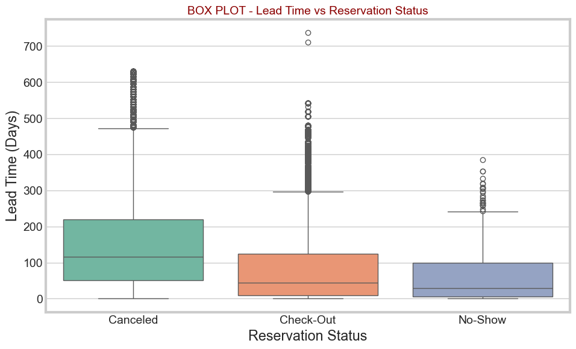

```python
plt.figure(figsize=(10,6))
plt.title("BOX PLOT - Lead Time vs Reservation Status", fontsize=14, color="darkred")
sns.boxplot(data=df, x="reservation_status", y="lead_time", palette=sns.color_palette("Set2"))
plt.xlabel("Reservation Status")
plt.ylabel("Lead Time (Days)")
plt.savefig("C:\Datasets\Bivariate_nc.png")
plt.show();
```

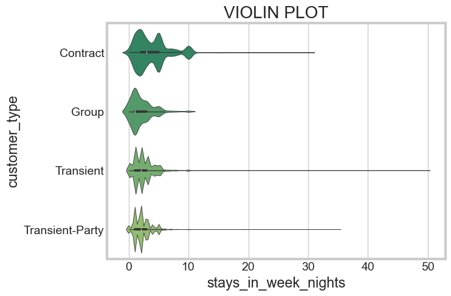

```python
plt.title("VIOLIN PLOT")
plt.savefig("C:\Datasets\Violin_plot.png")
sns.violinplot(data=df, y="customer_type", x="stays_in_week_nights",palette=sns.color_palette("summer"));
```

#### Multi-Variate Analysis

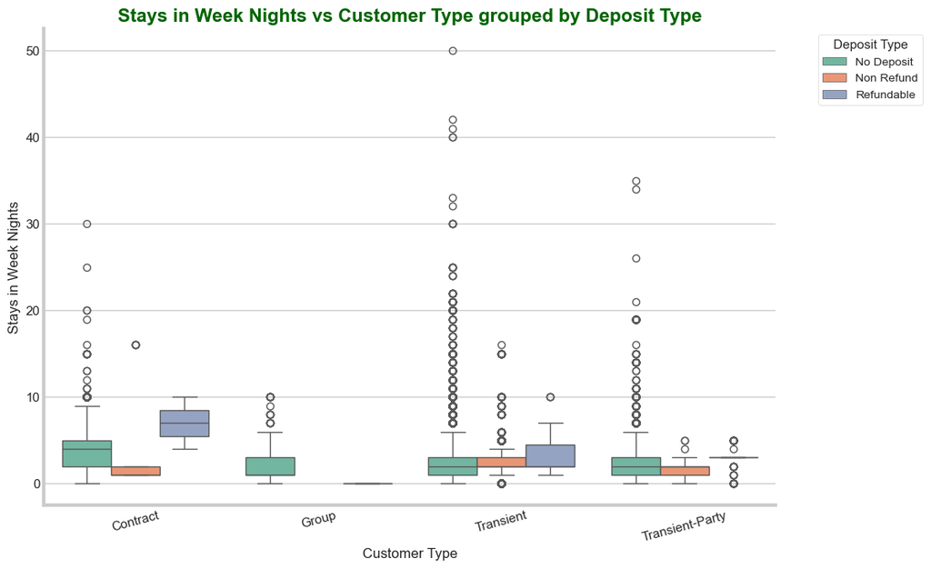

```python
plt.figure(figsize=(10,7))
sns.set_style("whitegrid")

sns.boxplot(
    x="customer_type",
    y="stays_in_week_nights",
    hue="deposit_type",
    data=df,
    palette="Set2"
)

plt.title("Stays in Week Nights vs Customer Type grouped by Deposit Type",
          fontsize=16, fontweight="bold", color="darkgreen")
plt.xlabel("Customer Type", fontsize=12)
plt.ylabel("Stays in Week Nights", fontsize=12)
plt.xticks(rotation=15, fontsize=11)
plt.yticks(fontsize=11)
plt.savefig("C:\Datasets\grouped box plots.png")

plt.legend(title="Deposit Type", fontsize=10, title_fontsize=11, bbox_to_anchor=(1.05, 1), loc="upper left")
sns.despine()

plt.show();
```

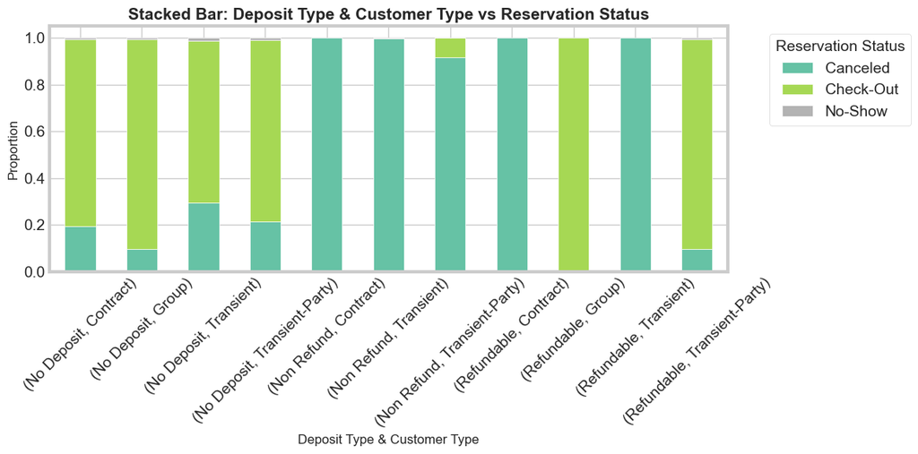

```python
cross_tab = pd.crosstab(
    [df['deposit_type'], df['customer_type']],
    df['reservation_status'],
    normalize='index'
)

cross_tab.plot(
    kind="bar",
    stacked=True,
    figsize=(12,6),
    colormap="Set2"
)

plt.title("Stacked Bar: Deposit Type & Customer Type vs Reservation Status", fontsize=15, fontweight="bold")
plt.ylabel("Proportion", fontsize=12)
plt.xlabel("Deposit Type & Customer Type", fontsize=12)
plt.xticks(rotation=45)
plt.legend(title="Reservation Status", bbox_to_anchor=(1.05, 1), loc='upper left')
plt.tight_layout()
plt.savefig("C:\Datasets\Stacked_bar_multivariate.png")
plt.show();
```

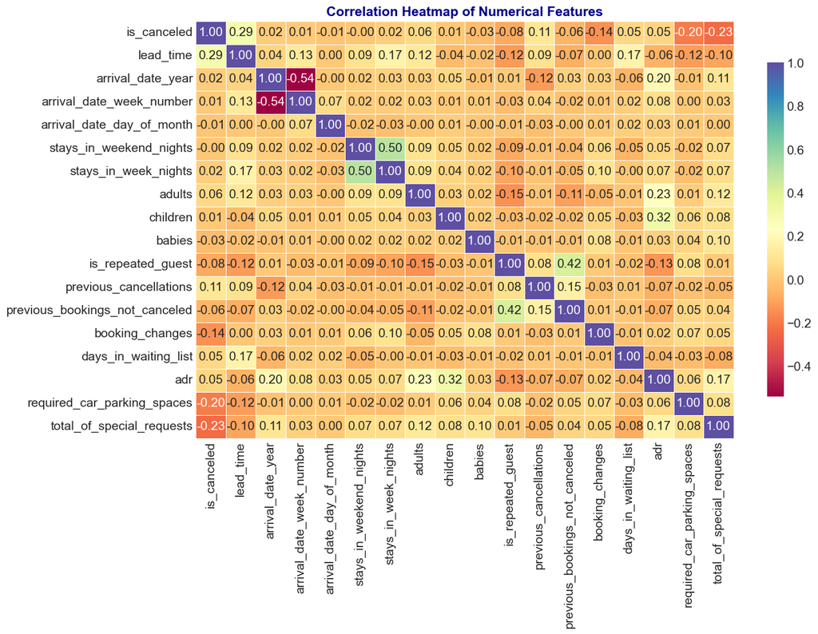

```python
plt.figure(figsize=(12,8))
sns.heatmap(
    df.corr(numeric_only=True),
    annot=True,
    fmt=".2f",
    cmap="Spectral",    # brighter + more aesthetic
    cbar_kws={'shrink': 0.8},
    linewidths=0.5,
    linecolor="white"
)
plt.title("Correlation Heatmap of Numerical Features", fontsize=15, fontweight="bold", color="darkblue")
plt.savefig("C:\Datasets\Heatmap_multivariate.png")
plt.show();
```

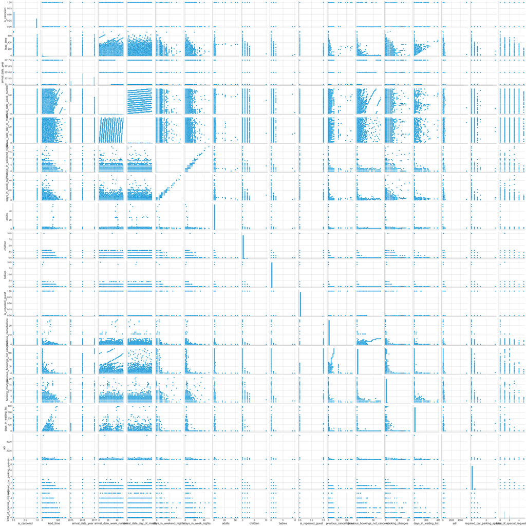

```python
sns.pairplot(df)
plt.savefig("C:\Datasets\Pairplot.png")
plt.show();
```